# Agriculture Crop Production in India

## Abstract

We would like to make an attempt to observe the production of agriculture in India on data available for 8 years. It is of interest to look into cost of cultivation, cost of production and yield of different crops in various states in India. We would also look into the production, land area used and yield of different crops.

In this study, we would mainly focus on the following:

- observing which agriculture crop has maximum production over the years
- observing which state has more yield and less cost of cultivation and production in various crops
- observing which crop is using lesser land area and giving more production and yield
- observing maximum number of varieties in a crop and their most common duration of cultivation and production

## Introduction

India is one of the major players in the agriculture sector worldwide and it is the primary source of livelihood for about 58% of India’s population. India’s production of food grains has been increasing every year, and India is among the top producers of several crops such as wheat, rice, pulses, sugarcane and cotton. It is the highest producer of milk and second highest producer of fruits and vegetables. In 2013, India contributed 25% to the world’s pulses production, the highest for any one country, 22% to the rice production and 13% to the wheat production. It also accounted for about 25% of the total quantity of cotton produced, besides being the second highest exporter of cotton for the past several years. Agriculture sector in India holds the record for second-largest agricultural land in the world generating employment for about half of the country’s population. Thus, farmers become an integral part of the sector to provide us with means of sustenance.

Key issues affecting agricultural productivity include the decreasing sizes of agricultural land holdings, continued dependence on the monsoon, inadequate access to irrigation, imbalanced use of soil nutrients resulting in loss of fertility of soil, uneven access to modern technology in different parts of the country, lack of access to formal agricultural credit, limited procurement of food grains by government agencies, and failure to provide remunerative prices to farmers.

## Data-set Description

The data-set consists of four tables holding the data of agriculture crop production.

Table 1:

- Crop : Agriculture Crop name
- 2004_05 : Production in the year 2004-05
- 2011_12 : Production in the year 2011-12

Table 2:

- Crop : Crop name
- State: State where crop is produced
- Cost_of_Cultivation_A2_FL : Cost of cultivation including out-of-pocket expenses incurred by the farmers and their family labour
- Cost_of_Cultivation_C2 : Comprehensive cost of cultivation including the imputed cost of capital
- Cost_of_Production_C2 : Cost of production including factor costs up to the stage of marketing the produce
- Yield : Amount of crop produced per unit land area

Table 3:

- Crop : Crop name
- Production_2006_07 : Crop production in 2006-07
- Area_2006_07 : Land area used for production in 2006-07
- Yield_2006_07 : Amount of crop produced in 2006-07

Table 4:

- Crop : Crop name
- Variety : Variety of the crop
- Season/Duration in days : Season or duration favorable for the crop
- Recommended zone : States or places and conditions recommended for crop production

## Graphical presentation of key variables

### Agriculture Production in every year

[figure not shown]

### Cropwise Analysis

[figure not shown]

### Crop-wise analysis with States

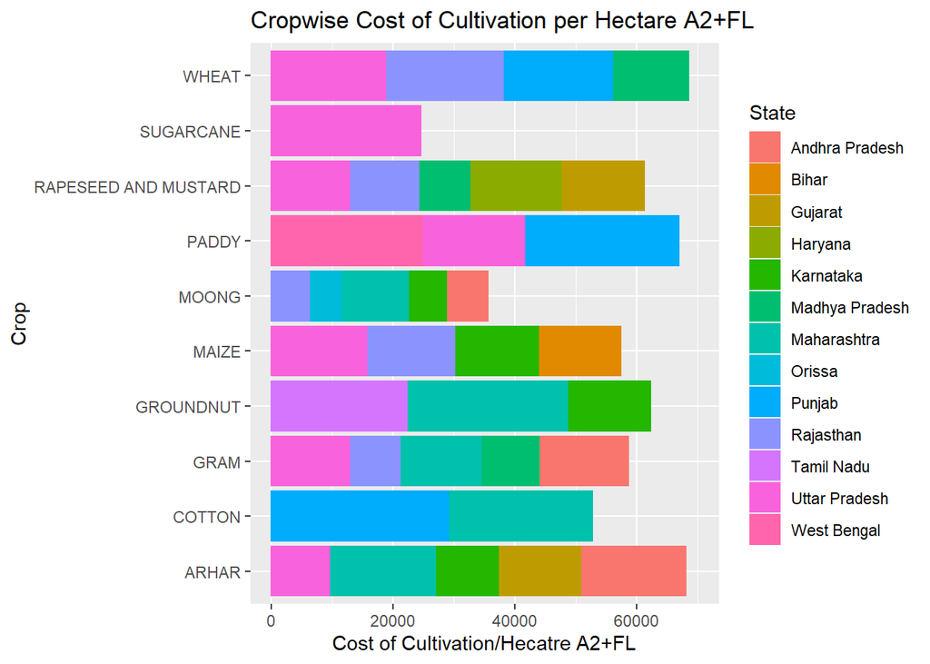

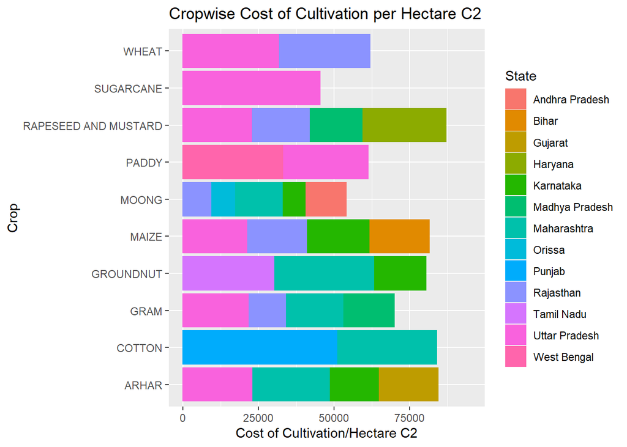

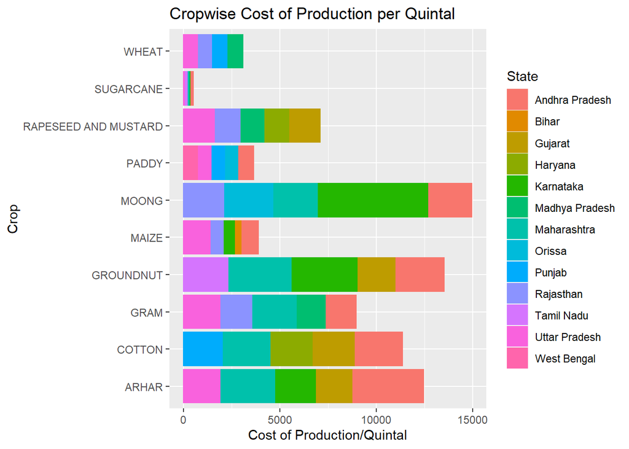

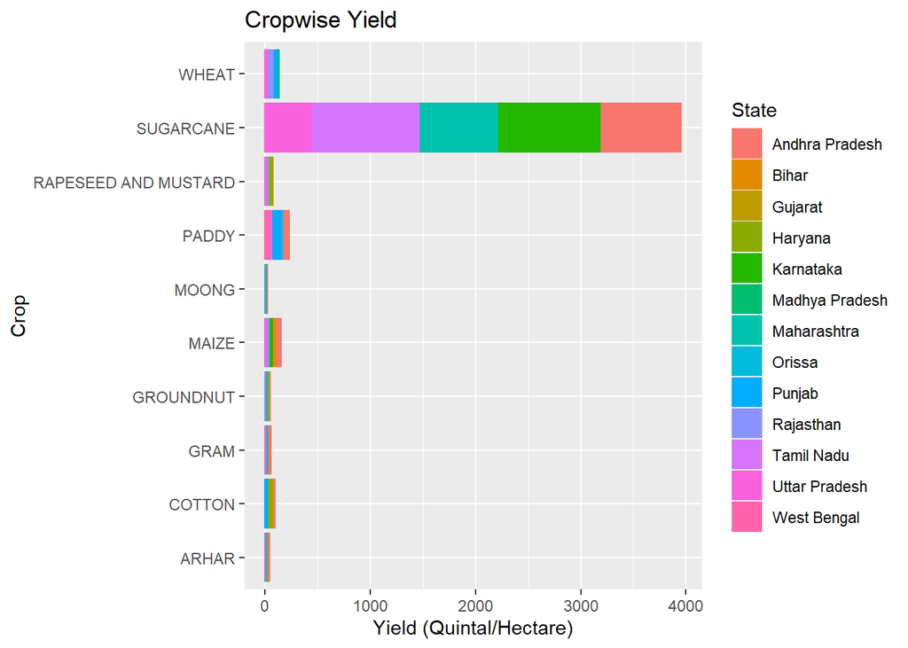

### State-wise Analysis

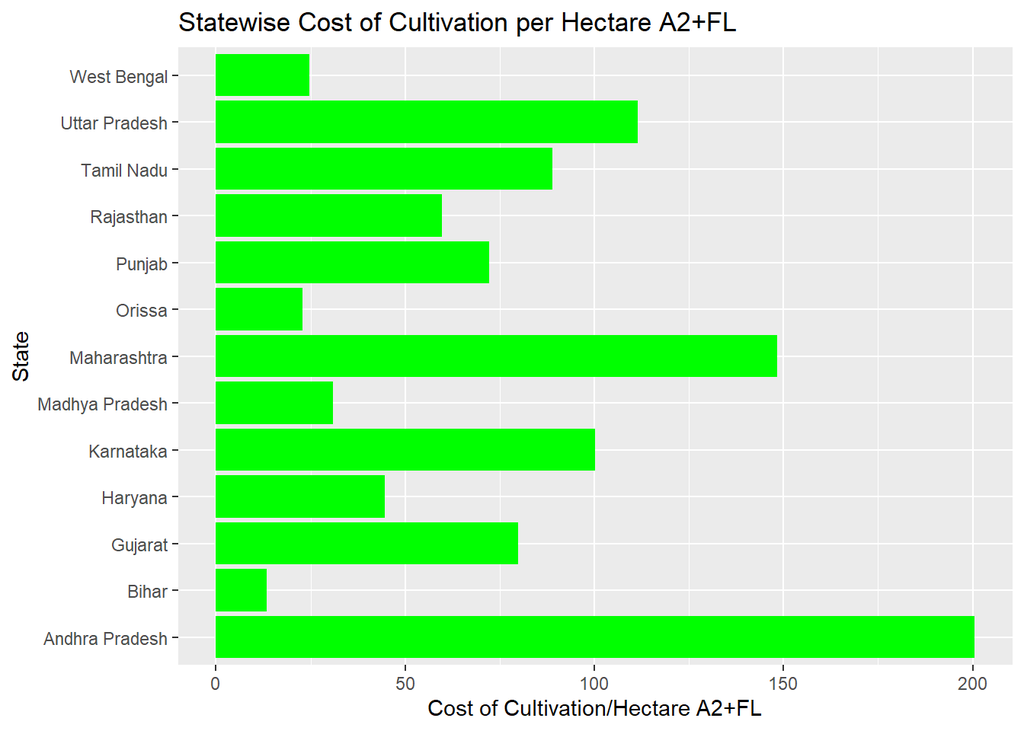

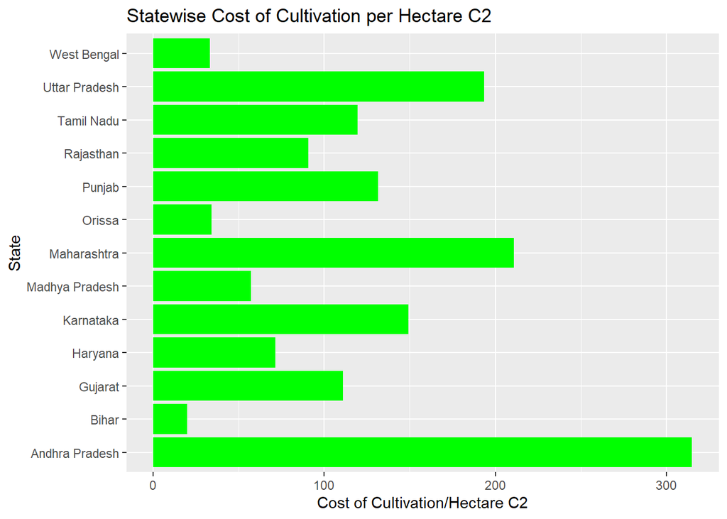

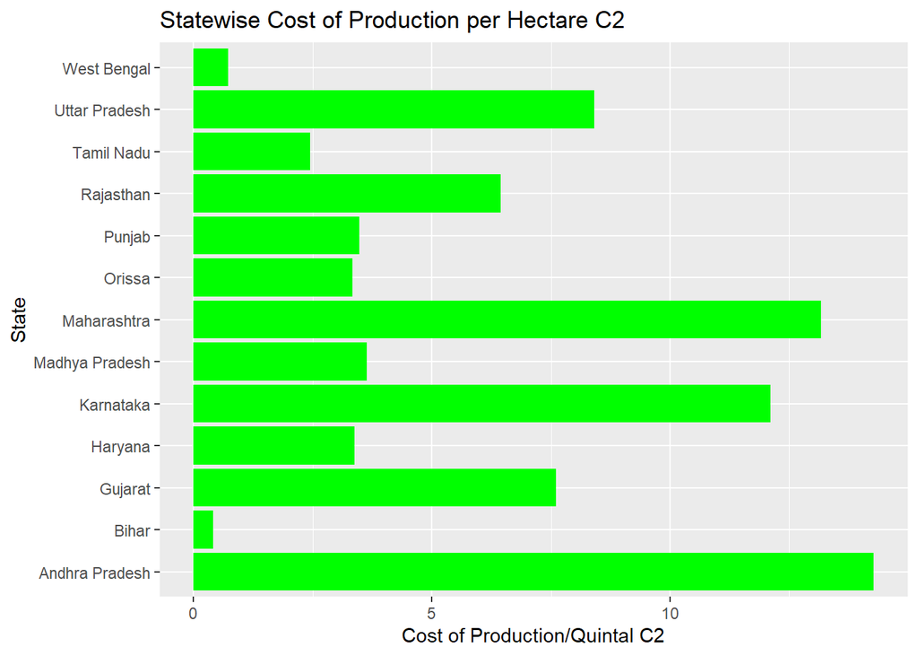

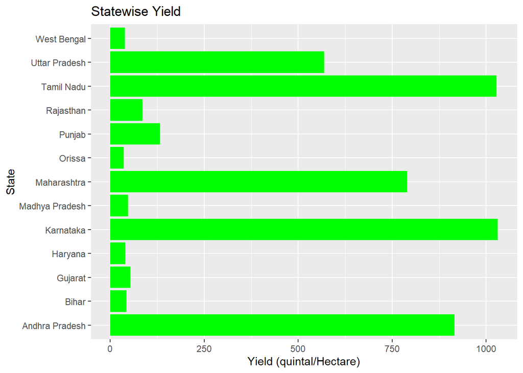

### Cost of Cultivation in every Crop

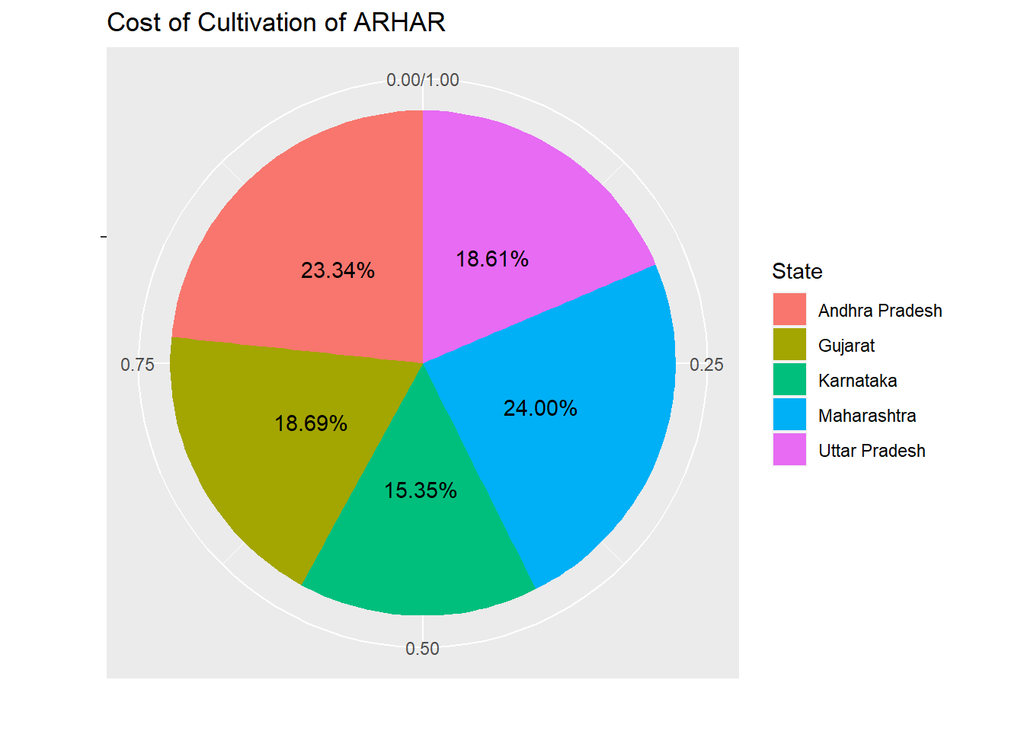

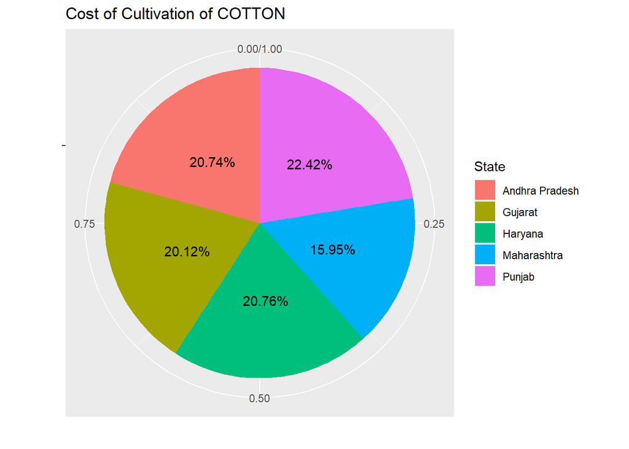

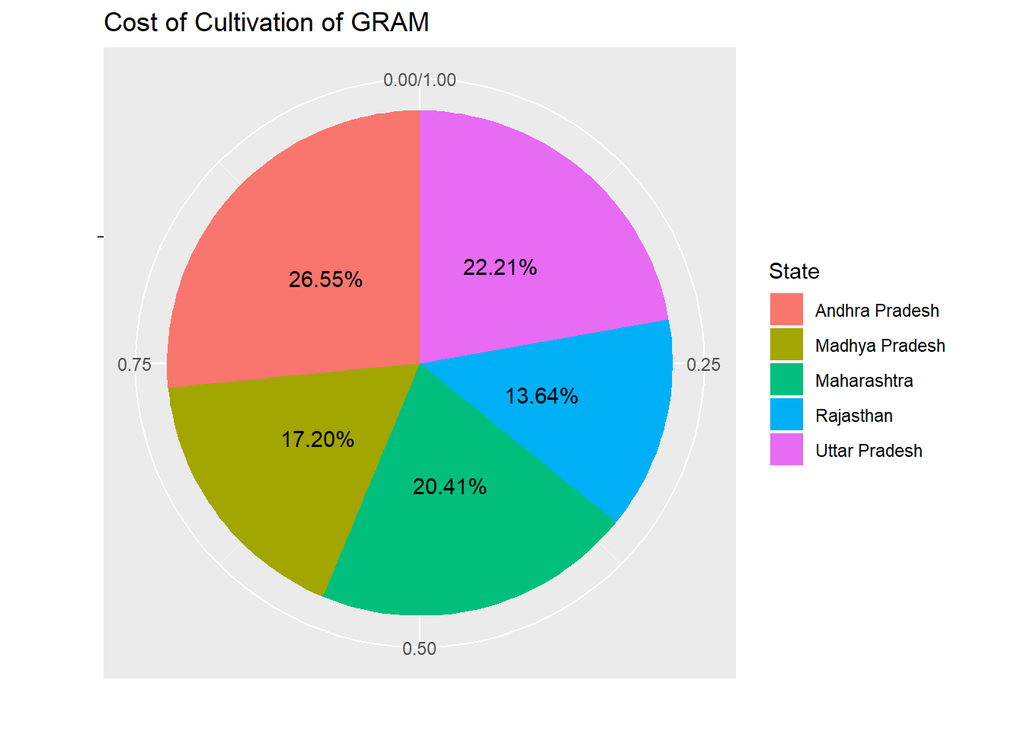

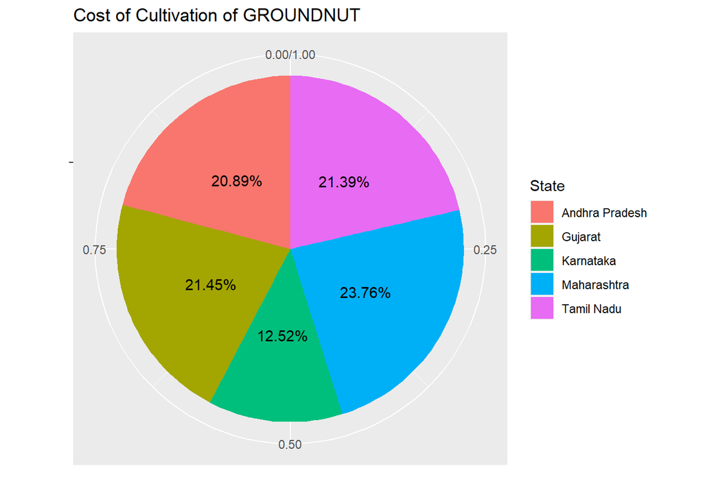

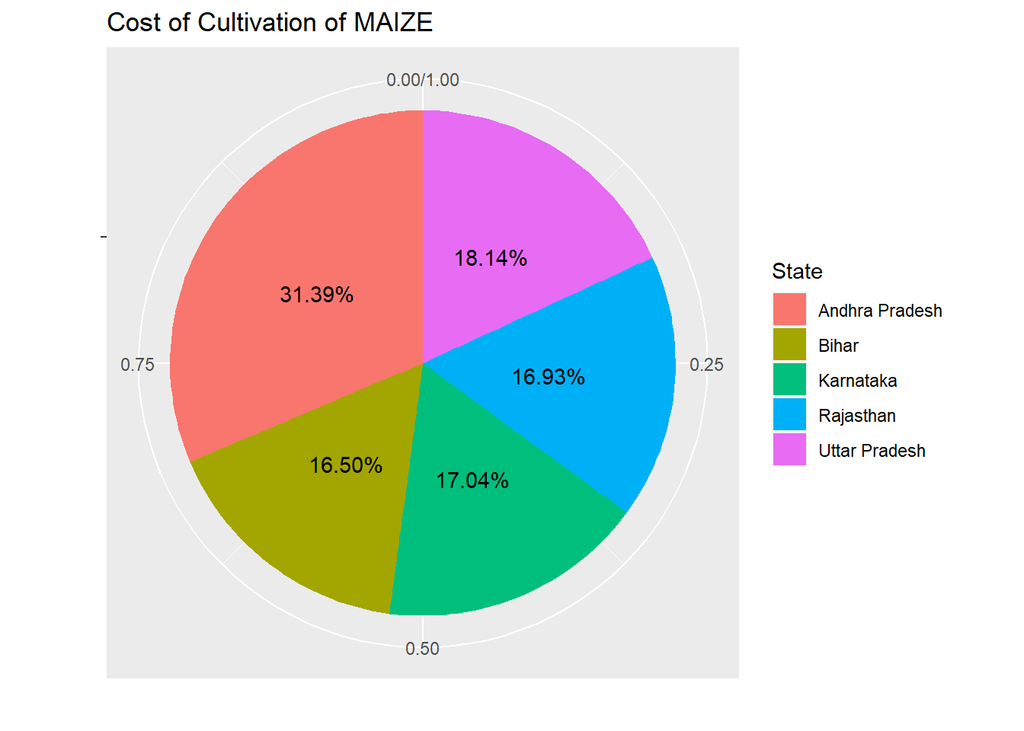

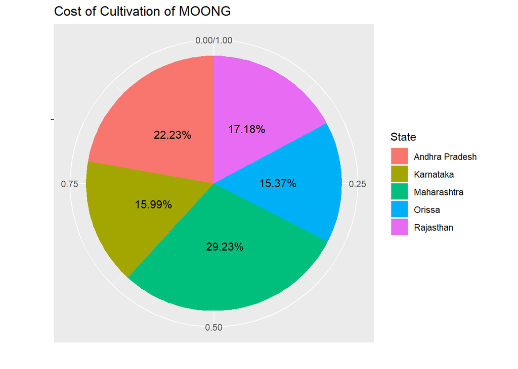

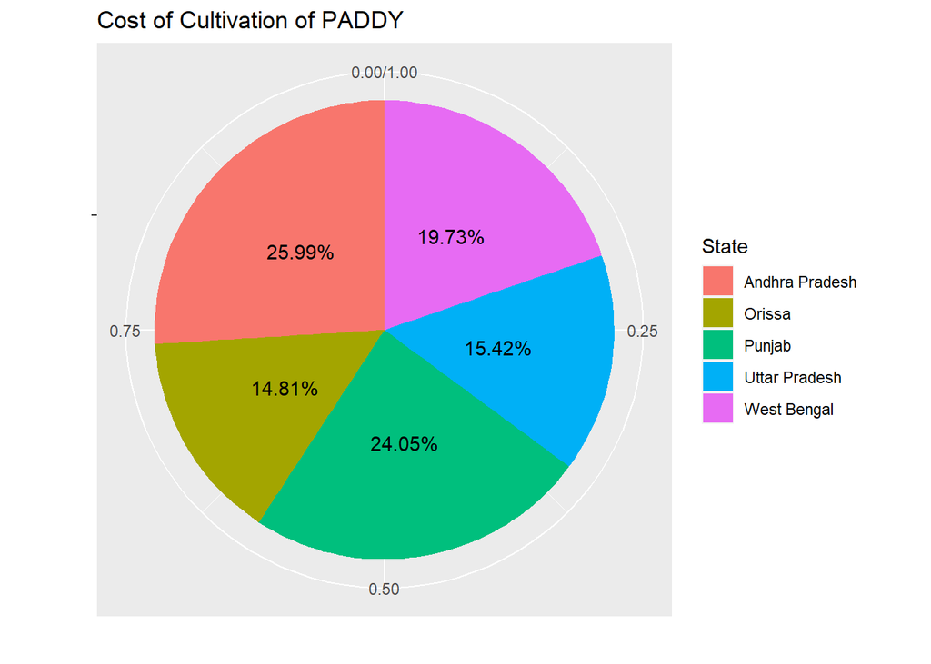

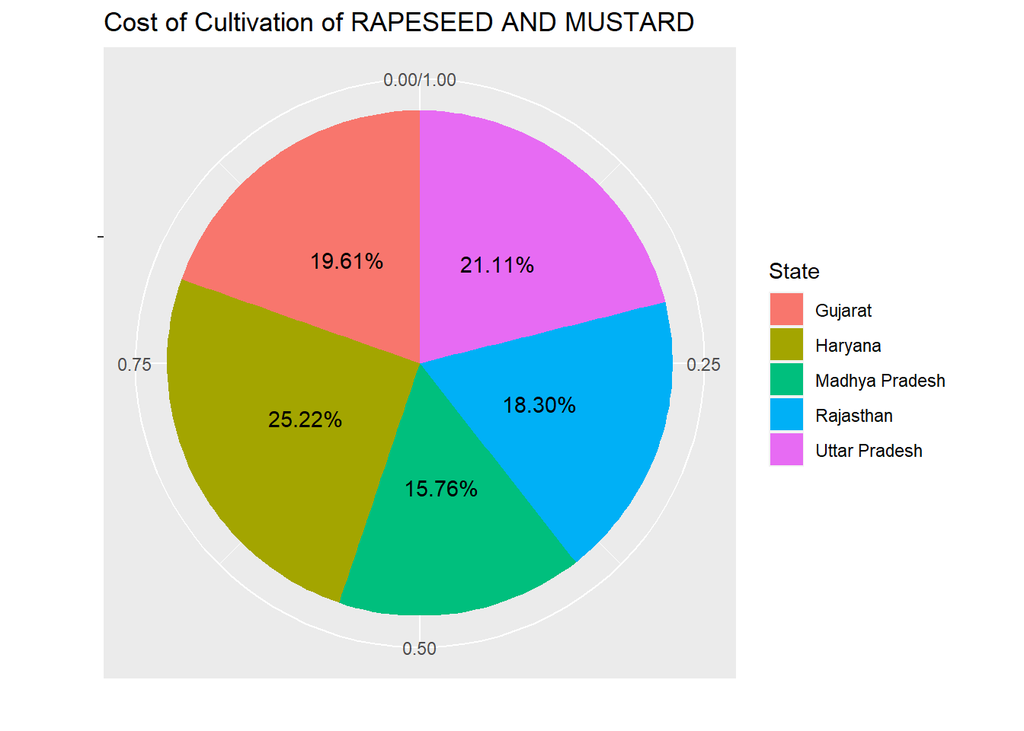

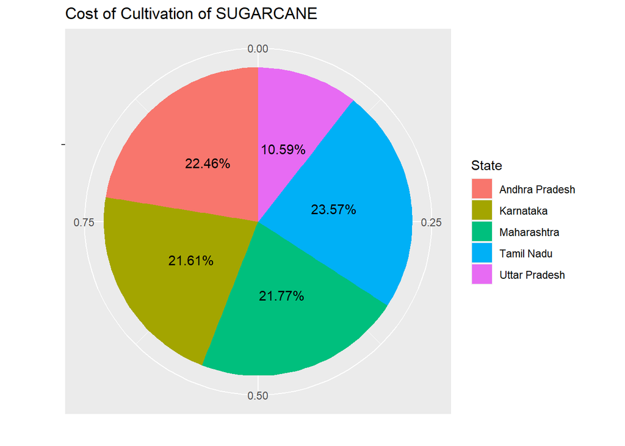

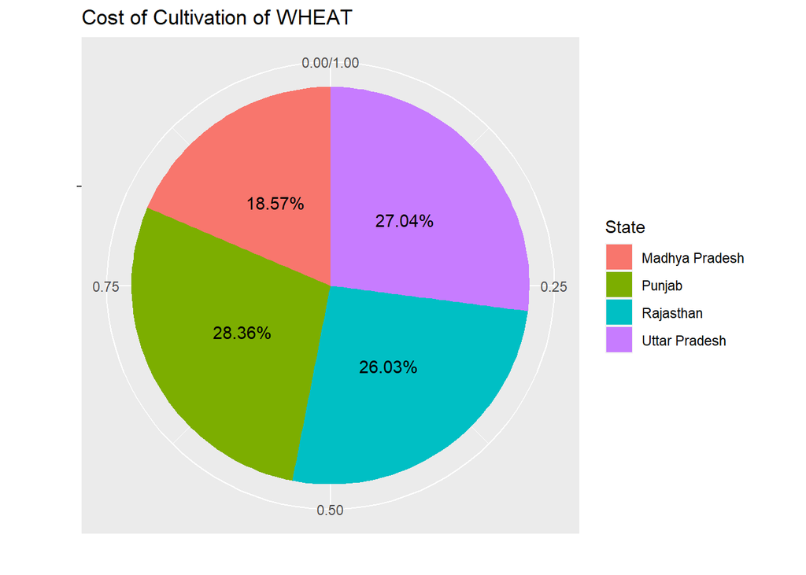

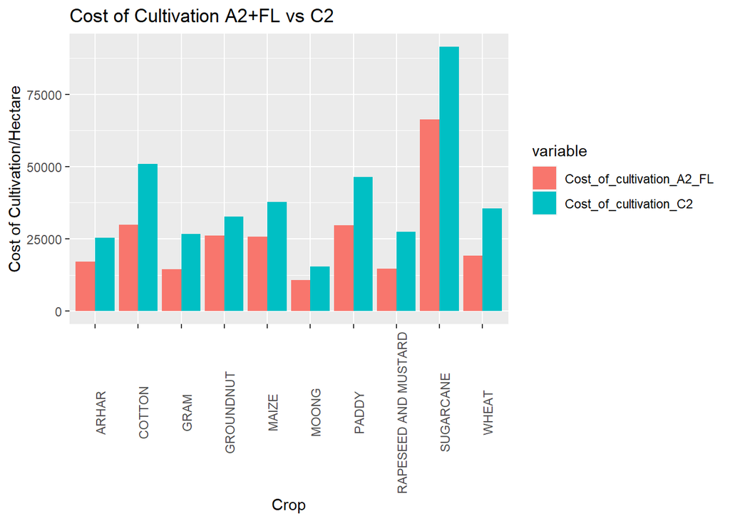

### Cost of Production in every crop

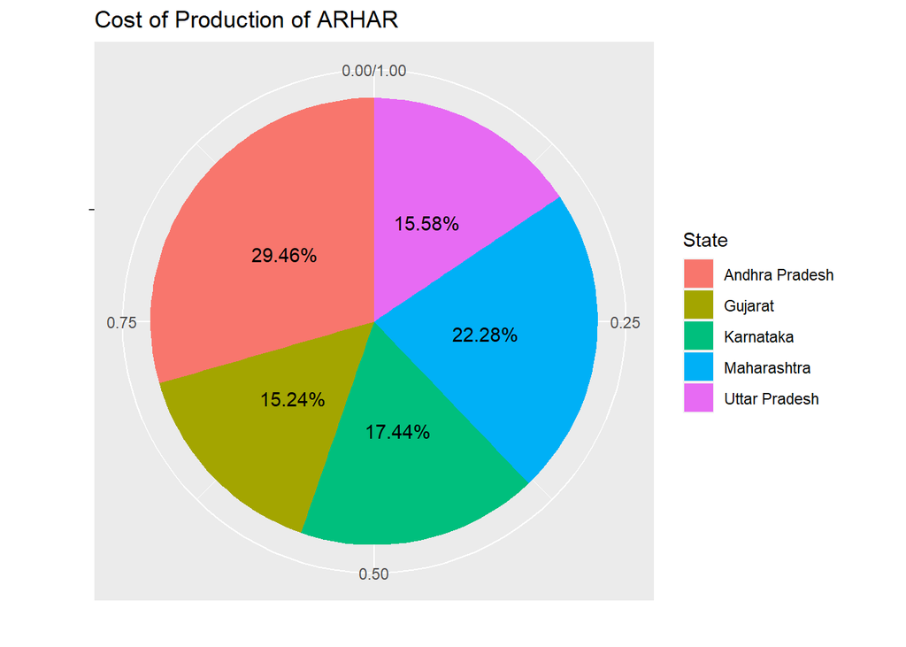

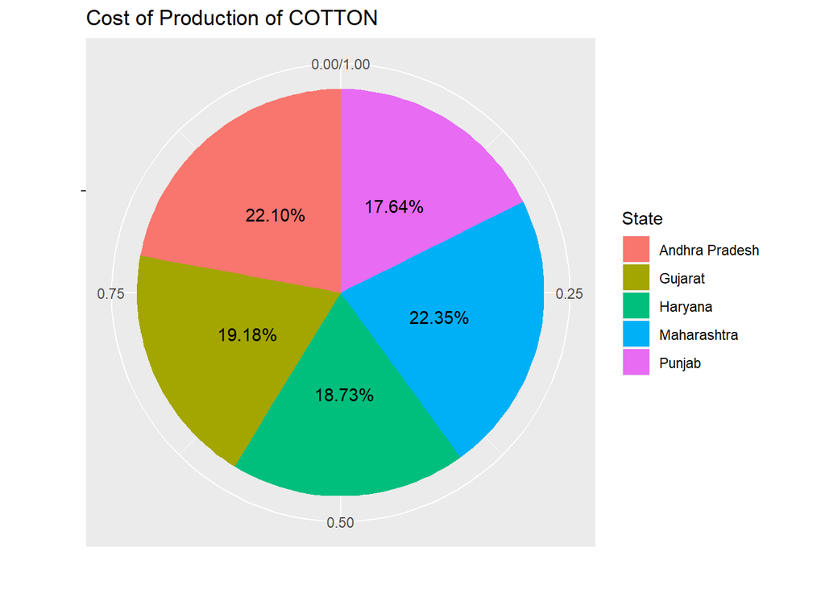

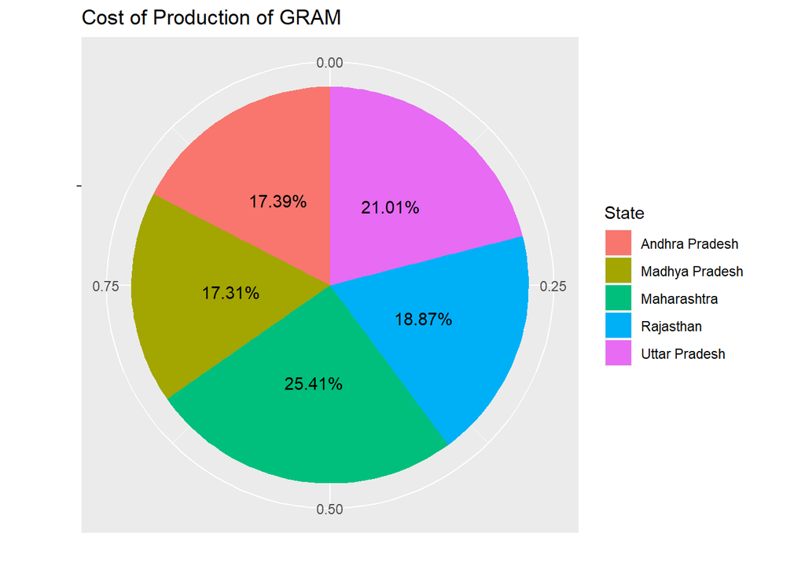

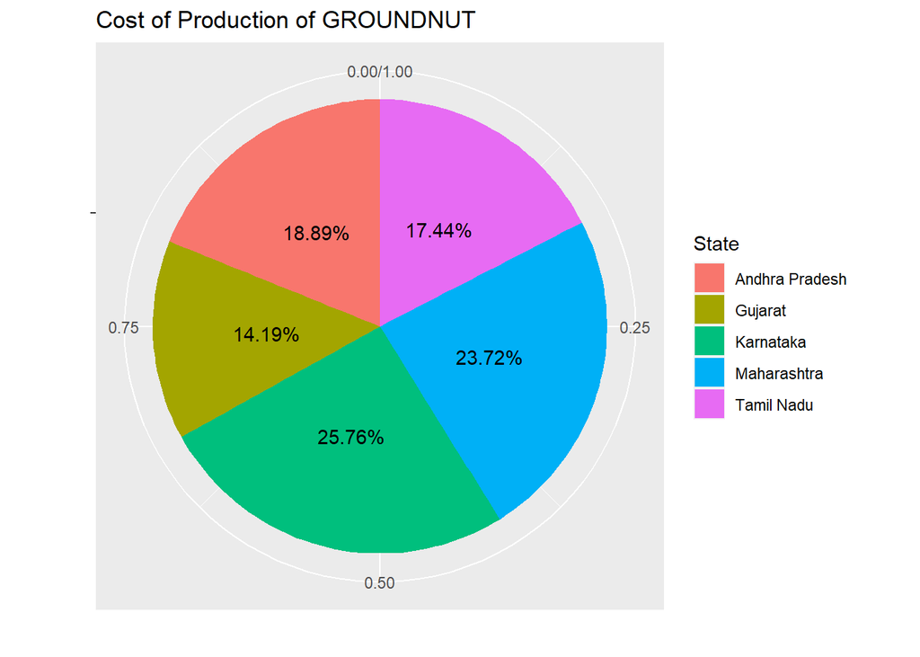

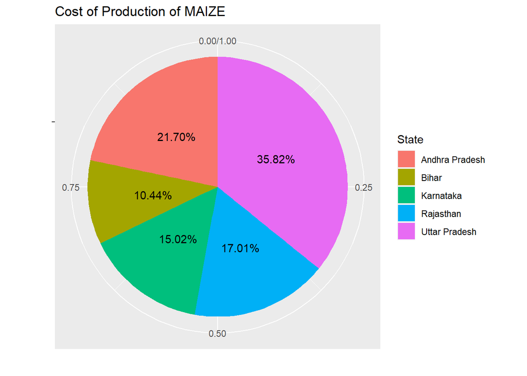

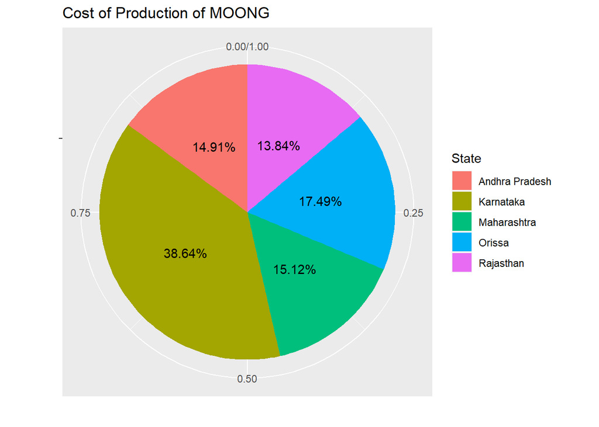

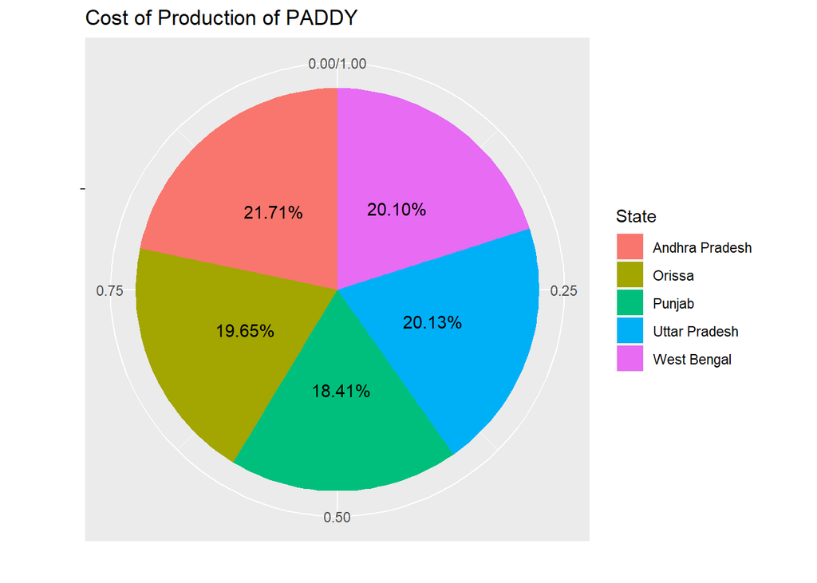

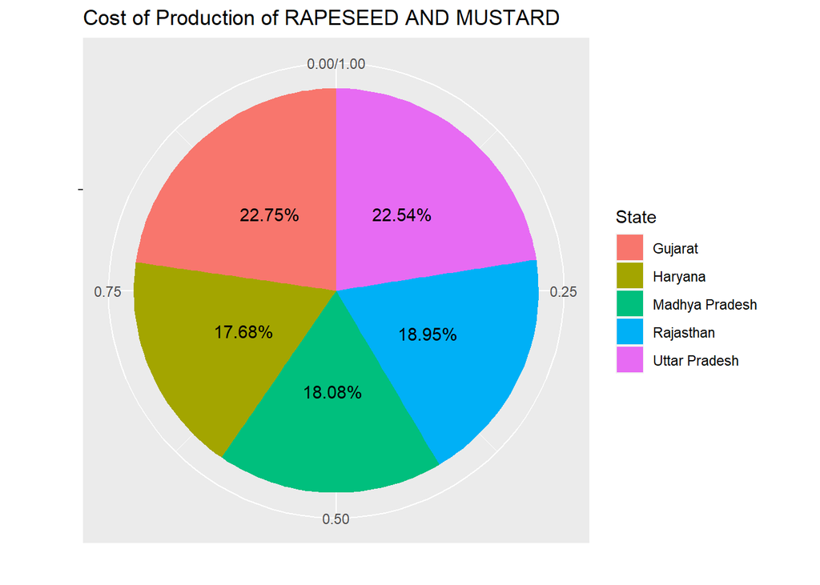

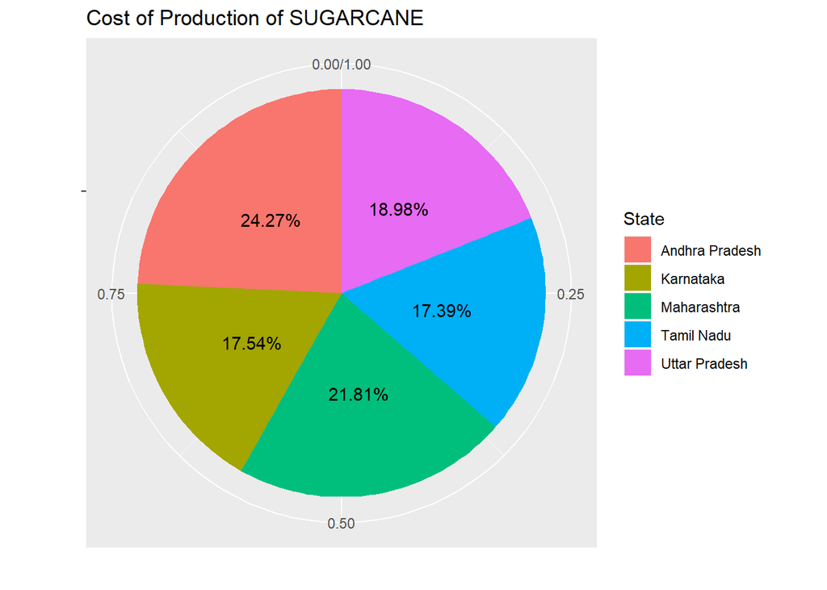

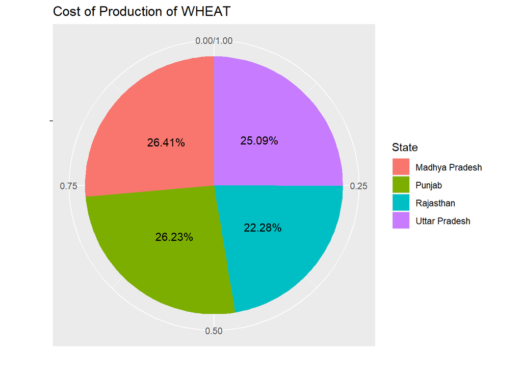